# ESCUELA POLITECNICA NACIONAL

# INGENIERIA EN CIENCIAS DE LA COMPUTACION

# Data Mining y Machine Learning

## 3 Hands On: Data Exploration

#### GR2CC_2023-1

## 1 Summarization

## Cargue el conjunto de datos carIns final. Ya tiene la imputación de valores faltantes.

### 1. Usando el paquete dplyr, responda las siguientes preguntas:

### (a) Obtenga el número de automóviles por estilo de carrocería.

```r
library('dplyr')
# Carga el archivo .Rdata
df <- load("C:\\Users\\Dany\\Documents\\R\\Hand 03\\carIns_final.Rdata")
#df <- load("Hand On 03\\data\\carIns_final.Rdata")

#carIns_final$bodyStyle

#unique(carIns_final$bodyStyle)

carIns_final %>% group_by(bodyStyle) %>% count()
```

| bodyStyle | n |
| --- | --- |
| convertible | 6 |
| hardtop | 8 |
| hatchback | 70 |
| sedan | 96 |
| wagon | 25 |

### (b) Obtenga el número de automóviles por bodyStyle y fuelType.

```r
carIns_final%>% group_by(bodyStyle, fuelType) %>% count()
```

| bodyStyle | fuelType | n |
| --- | --- | --- |
| convertible | gas | 6 |
| hardtop | diesel | 1 |
| hardtop | gas | 7 |
| hatchback | diesel | 1 |
| hatchback | gas | 69 |
| sedan | diesel | 15 |
| sedan | gas | 81 |
| wagon | diesel | 3 |
| wagon | gas | 22 |

### (c) Obtenga la media y la desviación estándar del atributo cityMpg por bodyStyle en orden ascendente.

```r
carIns_final %>% group_by(bodyStyle) %>% summarise(MediaCityMpg = mean(cityMpg), DesviacionCityMpg = sd(cityMpg))
```

| bodyStyle | MediaCityMpg | DesviacionCityMpg |
| --- | --- | --- |
| convertible | 20.50000 | 3.391165 |
| hardtop | 21.62500 | 5.423165 |
| hatchback | 26.31429 | 7.169870 |
| sedan | 25.32292 | 6.599035 |
| wagon | 24.04000 | 4.217819 |

### (d) También por body Style, y para los atributos city Mpg and highway Mpg, obtenga la media, la desviación estándar, la mediana y el rango intercuartil

```r
carIns_final %>% group_by(bodyStyle) %>% summarise(Media_CityMpg = mean(cityMpg), Desviacion_CityMpg = sd(cityMpg), Mediana_CityMpg = median(cityMpg), Rango_CityMpg = IQR(cityMpg), Media_highwayMpg = mean(highwayMpg), Desviacion_highwayMpg = sd(highwayMpg), Mediana_highwayMpg = median(highwayMpg), Rango_highwayMpg = IQR(highwayMpg))
```

| bodyStyle | Media_CityMpg | Desviacion_CityMpg | Mediana_CityMpg | Rango_CityMpg | Media_highwayMpg | Desviacion_highwayMpg | Mediana_highwayMpg | Rango_highwayMpg |
| --- | --- | --- | --- | --- | --- | --- | --- | --- |
| convertible | 20.50000 | 3.391165 | 21 | 5.25 | 26.00000 | 4.289522 | 27.0 | 3.00 |
| hardtop | 21.62500 | 5.423165 | 23 | 7.00 | 27.25000 | 6.088631 | 27.5 | 5.00 |
| hatchback | 26.31429 | 7.169870 | 26 | 12.00 | 32.17143 | 7.044314 | 31.5 | 11.75 |
| sedan | 25.32292 | 6.599035 | 25 | 11.25 | 30.83333 | 7.174027 | 30.5 | 11.25 |
| wagon | 24.04000 | 4.217819 | 24 | 5.00 | 28.72000 | 4.703899 | 29.0 | 7.00 |

## 2 Visualization

### 2. Con el paquete ggplot2, cree gráficos que le parezcan adecuados para responder a las siguientes preguntas.

### (e) Muestre la relación entre los atributos cityMpg y highwayMpg

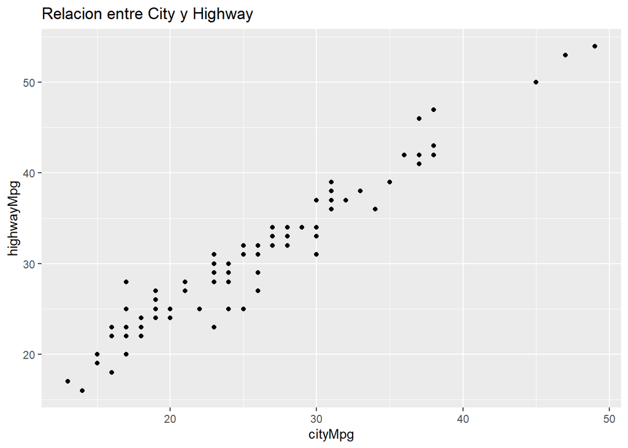

```r
library("ggplot2")

# ggplot crea graficos para presentar los resultados
ggplot(carIns_final, aes(x = cityMpg, y = highwayMpg)) +
  geom_point() +
  ggtitle("Relacion entre City y Highway")  # Agrega un titulo
```

### (f) Mostrar la distribución de automóviles por bodyStyle.

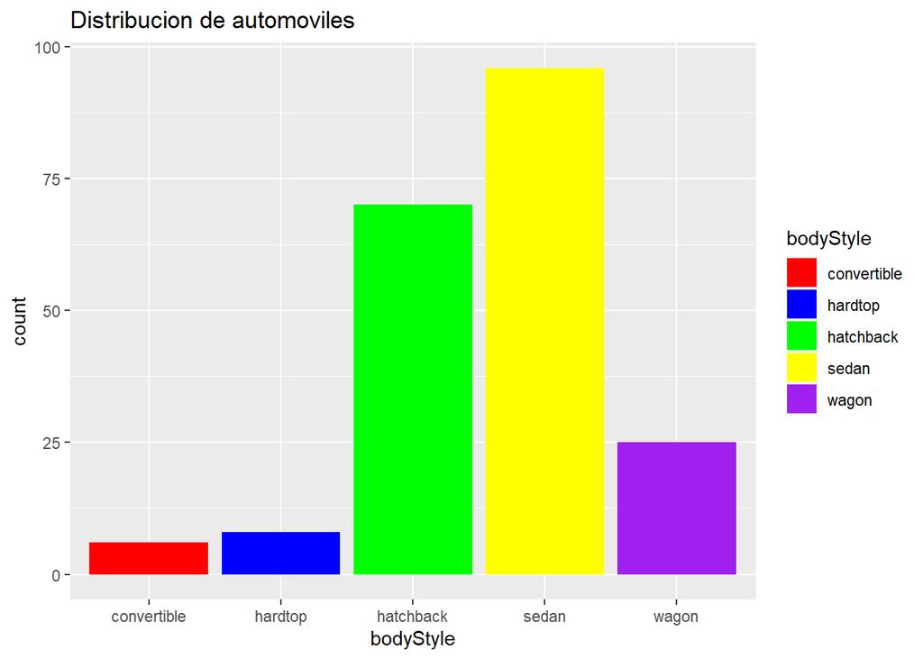

```r
ggplot(carIns_final, aes(x = bodyStyle, fill = bodyStyle)) +
  geom_bar() +
  scale_fill_manual(values = c('red', 'blue', 'green', 'yellow', 'purple')) +
  ggtitle("Distribucion de automoviles")
```

### (g) Mostrar la distribución de automóviles por precio. Sugerencia: cree contenedores de ancho igual a 5000.

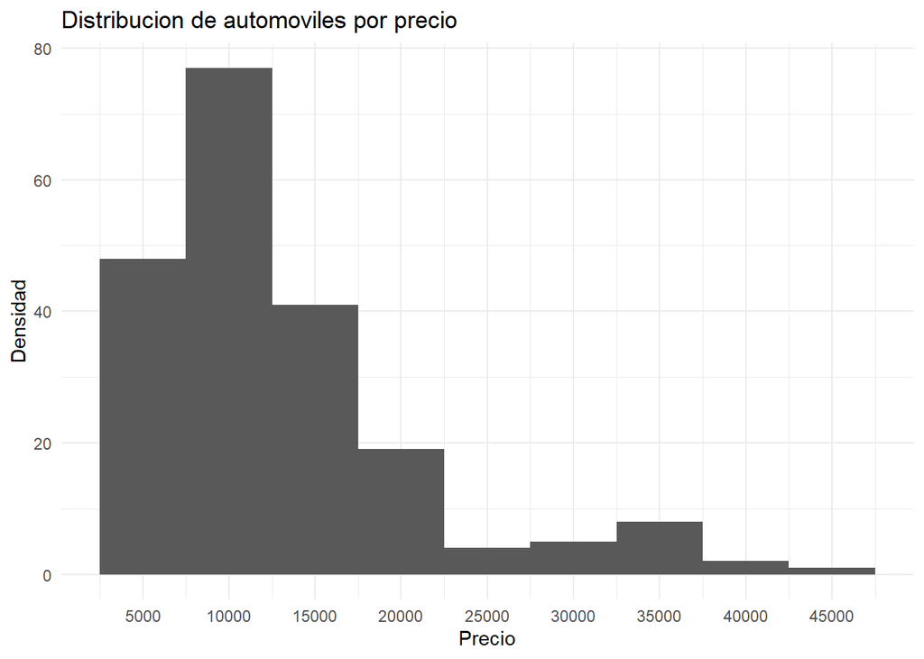

```r
ggplot(carIns_final, aes(x = price)) +
  #geom_density(adjust = 1) +   # Crea grafico de densidad
  geom_histogram(binwidth = 5000) +
  # Ajusta los contenedores de ancho igual a 5000
  scale_x_continuous(breaks = seq(0, max(carIns_final$price), 5000)) +
  labs(x = 'Precio', y = 'Densidad', title = 'Distribucion de automoviles por precio') +
  theme_minimal()
```

### (h) Agregue la información de la estimación de densidad al gráfico anterior.

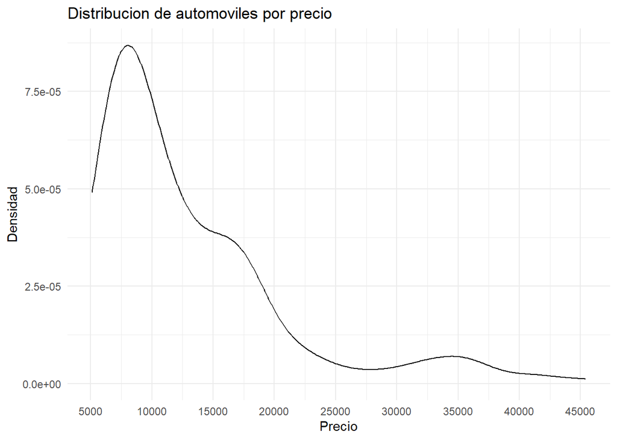

```r
ggplot(carIns_final, aes(x = price)) +
  geom_density() +   # Crea grafico de densidad
  # Ajusta los contenedores de ancho igual a 5000
  scale_x_continuous(breaks = seq(0, max(carIns_final$price), 5000)) +
  labs(x = 'Precio', y = 'Densidad', title = 'Distribucion de automoviles por precio') +
  theme_minimal()
```

### (i) Compruebe (visualmente) si es plausible considerar que el precio sigue una distribución normal.

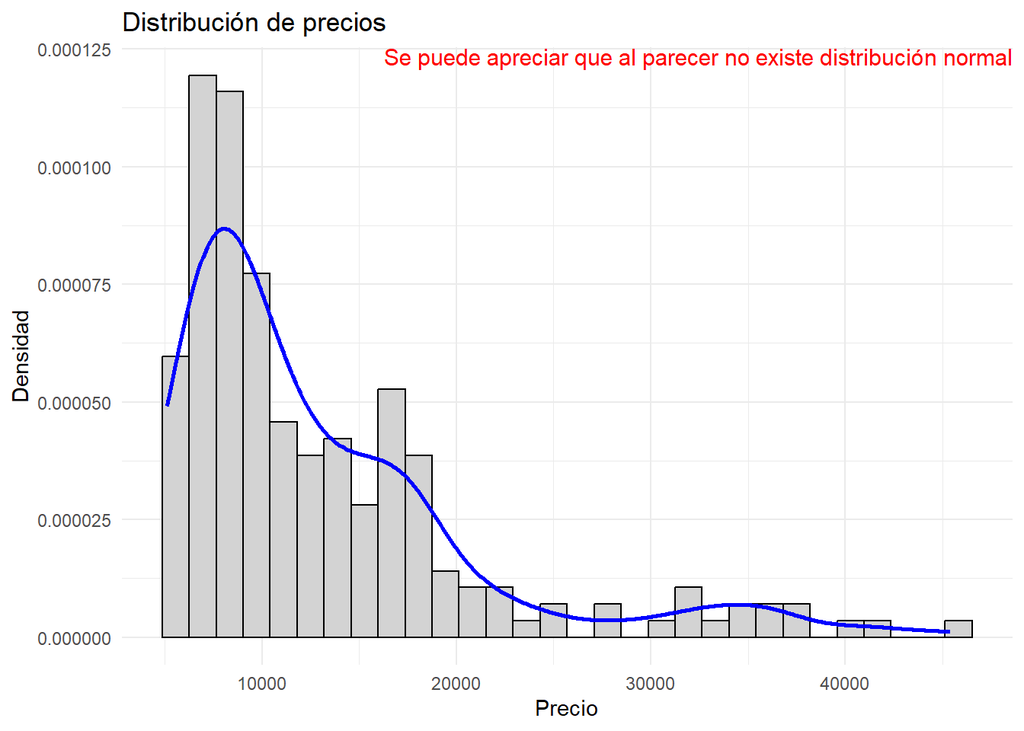

```r
library(ggplot2)

# Histograma de precios
ggplot(carIns_final, aes(x = price)) +
  geom_histogram(aes(y = ..density..), bins = 30, fill = "lightgray", color = "black") +
  labs(x = "Precio", y = "Densidad", title = "Distribución de precios") +
  theme_minimal() +

  # Curva de densidad teórica
  geom_density(color = "blue", size = 1) +

  # Anotación al final del gráfico
  annotate("text", x = Inf, y = Inf, label = "Se puede apreciar que al parecer no existe distribución normal",
           hjust = 1, vjust = 1, size = 4, color = "red")
```

### (j) Mostrar la distribución del price por atributo make. Sugerencia: use diagramas de caja y la función coord_flip().

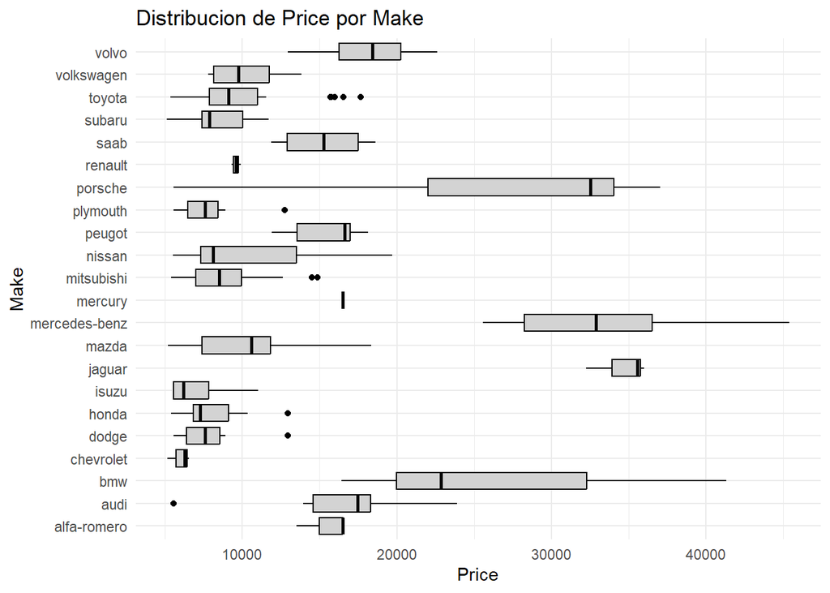

```r
library(ggplot2)

# Diagrama de caja de distribucion de precio por make
ggplot(carIns_final, aes(x = make, y= price)) +
  # Traza los diagramas de caja
  geom_boxplot(fill = "lightgray", color = "black") +  # fill = color de relleno, color = indica el color del contorno
  coord_flip() +    # El grafico se muestra horizontalmente
  labs(x = "Make", y = "Price", title = "Distribucion de Price por Make") +
  theme_minimal()
```

### (k) Muestre la distribución del price por atributo en nDoors. Sugerencia: utilice histogramas.

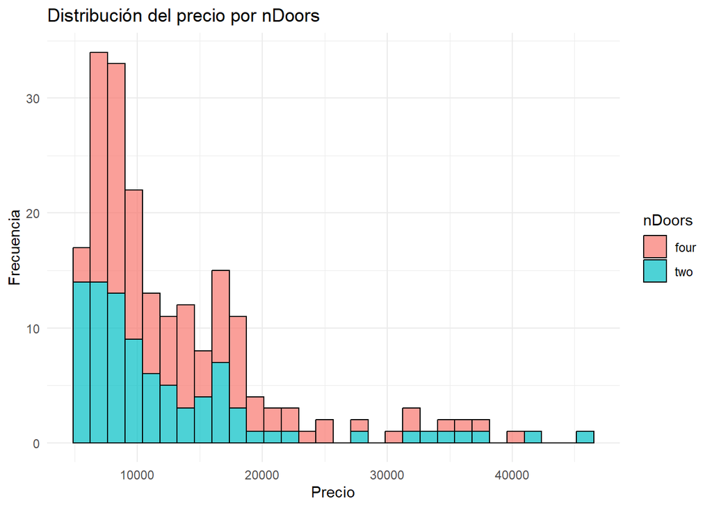

```r
library(ggplot2)

# Histograma de la distribución del precio por indoors
ggplot(carIns_final, aes(x = price, fill = nDoors)) +
  geom_histogram(bins = 30, color = "black", alpha = 0.7) +
  # bins indica el numero de intervalos del histograma
  # alpha defina la transparencia de las barras
  labs(x = "Precio", y = "Frecuencia", title = "Distribución del precio por nDoors") +
  theme_minimal()
```

### (l) Muestre la distribución del price por bodyStyle y el atributos nDoors. Sugerencia: utilice histogramas.

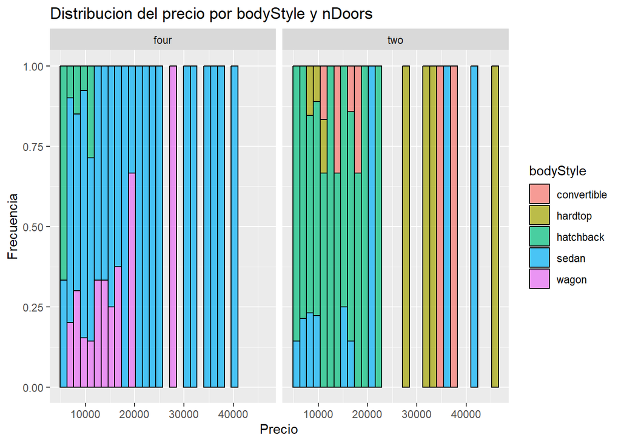

```r
library(ggplot2)

# Histograma de la distribucion del precio por bodyStyle y nDoors
ggplot(carIns_final, aes(x = price, fill = bodyStyle)) +
  geom_histogram(position = "fill", bins = 30, color = "black", alpha = 0.7) +
  # position = "fill" muestra las barras proporcionales al total de cada grupo
  # bins = 30 establece el numero de intervales del histograma
  facet_wrap(~nDoors) +     # Agrega paneles separados por los valores unicos del atributo "nDoors"
  labs(x = "Precio", y = "Frecuencia", title = "Distribucion del precio por bodyStyle y nDoors") +
  theme_grey()
```

### (m) Agregue el parámetro scales=“free_y” a la función de faceta en el gráfico anterior.

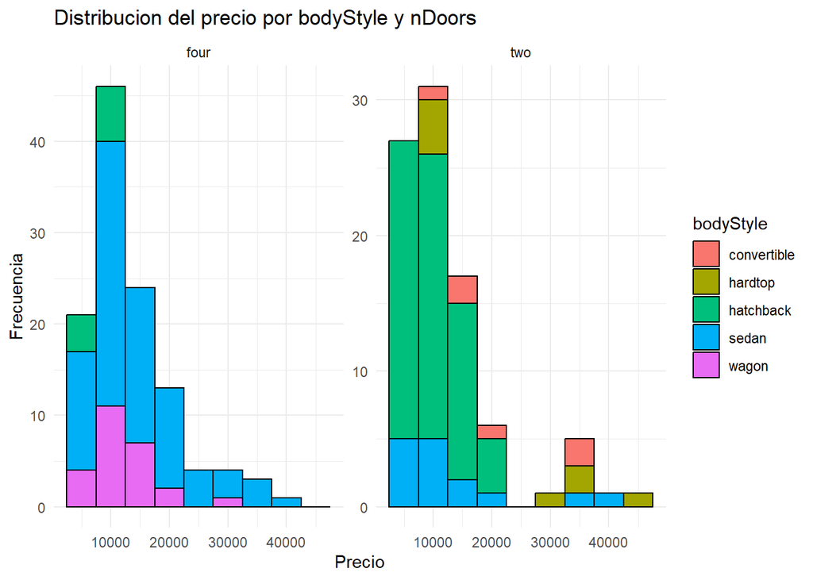

```r
library(ggplot2)

ggplot(carIns_final, aes(x = price, fill = bodyStyle)) +
  geom_histogram(binwidth = 5000, color = "black", aes(y = after_stat(count))) +
  # aes(y = ..count..) muestra el conteo de observaciones en el eje y del grafico de histograma
  facet_wrap(~nDoors, scales = "free_y") +
  # Al agregar scales = "free_y" a facet_wrap, cada panel del grafico tiene su propia escala en el eje Y
  labs(x = "Precio", y = "Frecuencia", title = "Distribucion del precio por bodyStyle y nDoors") +
  theme_minimal()
```

```r
# two y four son las categorias de la columna nDoors
```